### Mateusz Serek, 148284

### Mateusz Kądziela, 148271

Source code and more readable pseudocode available [here](https://github.com/MatKadd/EC_2023/tree/main/lab1).

# Imports

```python
import pandas as pd
import numpy as np
import matplotlib.pyplot as plt

from utils import (
    calculate_distances,
    get_solution_length,
    evaluate_solution,
    get_scores,
)
from algorithms import weighted_two_regret, two_regret
from visualisations import print_stats, visualize_solution, visualize_stats
```

We are given three columns of integers, with a row for each node. The first two columns contain x and y coordinates of the node positions in a plane. The third column contains node costs. The goal is to select exactly 50% of the nodes (if the number of nodes is odd we round the number of nodes to be selected up) and form a Hamiltonian cycle (closed path) through this set of nodes such that the sum of the total length of the path plus the total cost of the selected nodes is minimized. The distances between nodes are calculated as Euclidean distances rounded mathematically to integer values. The distance matrix should be calculated just after reading an instance and then only the distance matrix (no nodes coordinates) should be accessed by optimization methods to allow instances defined only by distance matrices.

# Reading data

```python
A = pd.read_csv("../data/TSPA.csv", sep=";", header=None)
A.name = "Instance A"
B = pd.read_csv("../data/TSPB.csv", sep=";", header=None)
B.name = "Instance B"
C = pd.read_csv("../data/TSPC.csv", sep=";", header=None)
C.name = "Instance C"
D = pd.read_csv("../data/TSPD.csv", sep=";", header=None)
D.name = "Instance D"

instances = [A, B, C, D]
```

# Pseduocode for algorithms

### 2-regret

Function two_regret(distances, start_node): distances_copy <- Copy(distances) solution <- Array of size 2 in_solution <- Empty Set If start_node is None: solution[0] <- Randomly select a node from 0 to length of distances Else: solution[0] <- start_node Add solution[0] to in_solution solution[1] <- Node with the minimum distance to solution[0] Add solution[1] to in_solution For num_nodes in from 2 to Calculate_solution_length(length of distances): biggest_regret <- Negative infinity biggest_regret_node <- None biggest_regret_insertion <- None For each point in the set of all nodes: If point is not in in_solution: smallest_distance <- Positive infinity second_smallest_distance <- Positive infinity current_smallest_insertion <- None For each insertion_place from 0 to num_nodes: dist_change <- Calculate_distance_change(solution, distances_copy, insertion_place, point) If dist_change < smallest_distance: second_smallest_distance <- smallest_distance smallest_distance <- dist_change current_smallest_insertion <- insertion_place ElseIf dist_change < second_smallest_distance: second_smallest_distance <- dist_change Regret <- second_smallest_distance - smallest_distance If Regret > biggest_regret: biggest_regret <- Regret biggest_regret_node <- point biggest_regret_insertion <- current_smallest_insertion Insert biggest_regret_node into solution at position (biggest_regret_insertion + 1) Add biggest_regret_node to in_solution Return solution

### Weighted 2-regret

Function weighted_two_regret(distances, start_node): distances_copy <- Copy(distances) solution <- Array of size 2 in_solution <- Empty Set If start_node is None: solution[0] <- Randomly select a node from 0 to length of distances Else: solution[0] <- start_node Add solution[0] to in_solution solution[1] <- Node with the minimum distance to solution[0] Add solution[1] to in_solution For num_nodes from 2 to Get_solution_length(length of distances): smallest_weighted_sum <- Positive infinity smallest_weighted_sum_node <- None smallest_weighted_sum_insertion <- None For point from 0 to length of distances: If point is not in in_solution: smallest_distance <- Positive infinity second_smallest_distance <- Positive infinity current_smallest_insertion <- None For insertion_place from 0 to num_nodes: dist_change <- ( distances[solution[insertion_place], point] + distances[point, solution[(insertion_place + 1) % num_nodes]] - distances[ solution[insertion_place], solution[(insertion_place + 1) % num_nodes] ] ) If dist_change < smallest_distance: second_smallest_distance <- smallest_distance smallest_distance <- dist_change current_smallest_insertion <- insertion_place ElseIf dist_change < second_smallest_distance: second_smallest_distance <- dist_change weighted_regret <- distances[point, point] - ( second_smallest_distance - smallest_distance ) If weighted_regret < smallest_weighted_sum: smallest_weighted_sum <- weighted_regret smallest_weighted_sum_node <- point smallest_weighted_sum_insertion <- current_smallest_insertion Insert smallest_weighted_sum_node into solution at position (smallest_weighted_sum_insertion + 1) Add smallest_weighted_sum_node to in_solution Return solution

# Experminets

When calculating distances, we incorporated node costs into them, so basically distance(i, j) = euclidean_distance(i, j) + node_cost(j).

```python
def analyze_instances(instances, methods):
    for instance in instances:
        print(f"Statistics for: {instance.name}")
        distances = calculate_distances(instance)
        for method in methods:
            scores, best = get_scores(method, distances)
            visualize_stats(scores, method.__name__)
            visualize_solution(instance, best)
```

Run experiments for each instance and show their results.

```
Statistics for: Instance A
Min score for two_regret: 104829
Max score for two_regret: 124764
Avg score for two_regret: 115947.625
```

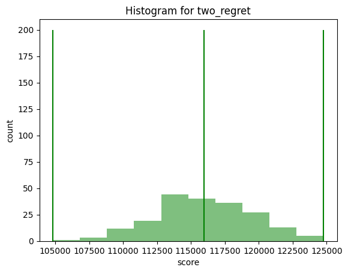

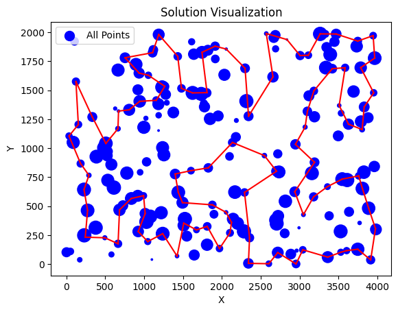

```
Min score for weighted_two_regret: 74026
Max score for weighted_two_regret: 77172
Avg score for weighted_two_regret: 75780.225
```

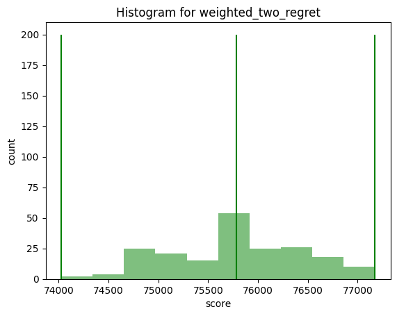

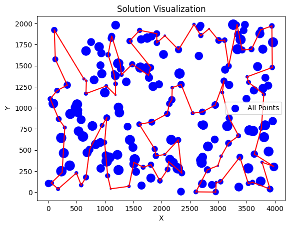

```
Statistics for: Instance B
Min score for two_regret: 109774
Max score for two_regret: 128550
Avg score for two_regret: 119176.07
```

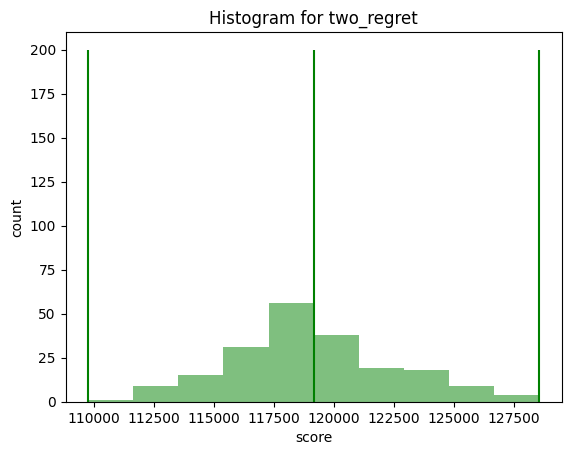

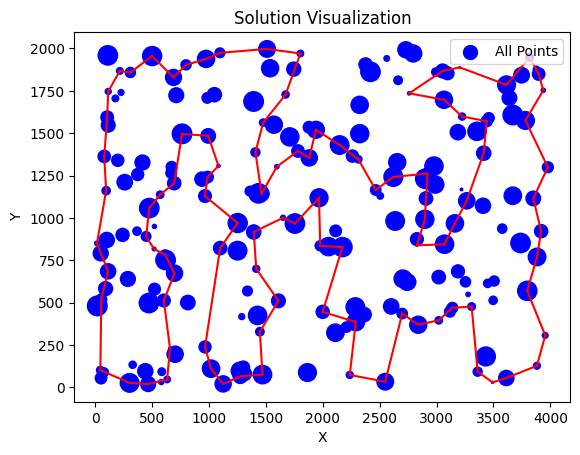

```
Min score for weighted_two_regret: 66986
Max score for weighted_two_regret: 70013
Avg score for weighted_two_regret: 68662.945
```

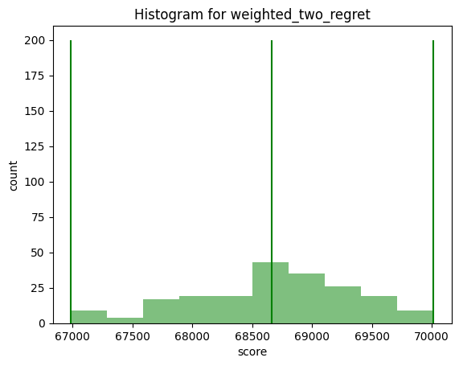

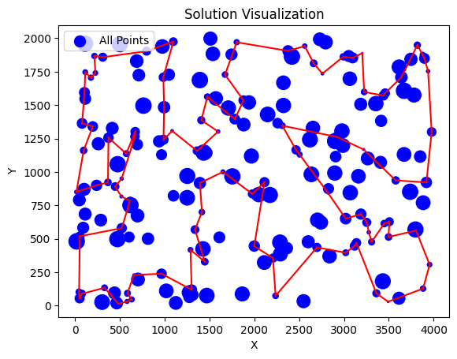

```
Statistics for: Instance C
Min score for two_regret: 65016
Max score for two_regret: 73090
Avg score for two_regret: 68975.175
```

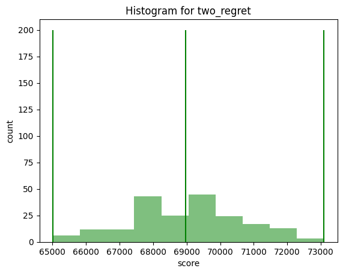

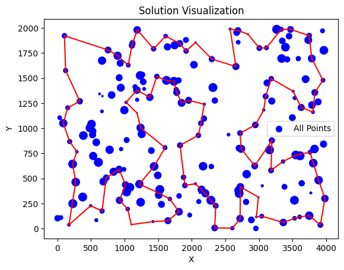

```
Min score for weighted_two_regret: 49124
Max score for weighted_two_regret: 51830
Avg score for weighted_two_regret: 50452.365
```

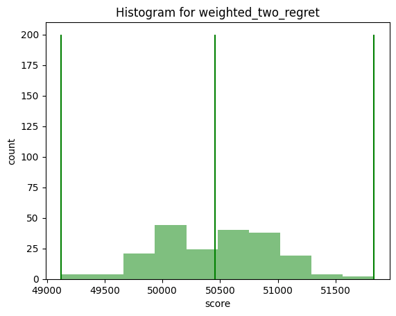

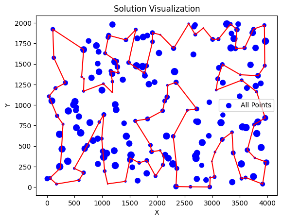

```
Statistics for: Instance D
Min score for two_regret: 64682
Max score for two_regret: 76201
Avg score for two_regret: 70813.235
```

[4 more figures not shown]

```python
analyze_instances(instances, [two_regret, weighted_two_regret])
```

# Conclusions

From the plots we can see that the two regret method tends to ignore sizes of nodes (costs of entering them) and the weighted two regret avoids them and picks most of the smallest nodes. The result of weighted regret being better than standard one is expected, as the standard method does not take node sizes into account when calculating the regret value which misses some valuable information. This information is used by weighted two regret method, which results in a solid, expected improvement.